# Monitoria I Heterocedasticidade

Giovanna Quintao

01 de setembro de 2020

Antes de iniciar, vamos instalar os pacotes necessários (comando install.packages) e depois requisitar eles (comando library). Depois de instalado em seu computador, não precisa instalar mais, só requisitar.

Por isso, depois de instalar, coloque um # em frente ao install.packages para que não instale novamente. (Quando se coloca um # em frente ao comando, esse comando se torna um comentário)

```r
#install.packages("tidyverse")  #pacote para limpar as bases e plotar graficos
#install.packages("lmtest") #pacote para fazer testes de regressão multipla
#install.packages("sandwich") #pacote para calcular erros padrões robustos


library(tidyverse)
library(lmtest)
library(sandwich)


options(scipen = 999) #Desligamos a notação cientifica
```

# 1 Base de dados

A base de dados utilizada será uma base fictícia. As variáveis contidas nelas são as seguintes:

| X | Variável de contagem |
| --- | --- |
| id_dom | Variável identificadora do domicílio |
| uf | Estado |
| renda | Rendimento mensal em dinheiro no trabalho principal da semana de referência |
| raca | Dummy indicando 1=Branco,0=Negro |
| anos_estudo | Número de anos de estudo |
| idade | Idade |
| sexo | Dummy indicando 1=Homens, 0=Mulheres |

Foram feitos alguns ajustes para facilitar o exercício: foram removidos observações que não continham alguma dessas variáveis, e a variável de anos de estudo varia de 0 a 17 anos.

Vamos abrir a base de dados e nomea-la como “df” (abreviação de data frame). Lembre-se que para abrir a base de dados, ela deve estar na pasta do seu projeto. Caso não esteja na pasta, você pode colocar o endereço completo de onde esteja.

```r
df<-data.table::fread("base_ficticia_heterocedasticidade.csv")
```

Vamos ver como a base de dados está.

```r
head(df)
```

```
##       V1          id_dom uf renda raca anos_estudo idade sexo
## 1: 90534 201535000015002 35  6000    1          16    51    0
## 2: 90535 201535000015002 35  2500    1          16    40    1
## 3: 90536 201535000015003 35  1500    0          15    53    0
## 4: 90537 201535000015003 35  1500    0          16    56    1
## 5: 90538 201535000015005 35  3000    1          14    24    1
## 6: 90539 201535000015010 35  1600    1          11    56    0
```

Vamos criar uma variável de idade ao quadrado

```r
df$idade2<-(df$idade)^2
```

# 2 Regressão

Vamos fazer uma regressão múltipla baseada na regressão de Mincer (1974).

```r
MQO<-lm(renda~anos_estudo+raca+idade+idade2+sexo, data=df)
```

```r
summary(MQO)
```

```
##
## Call:
## lm(formula = renda ~ anos_estudo + raca + idade + idade2 + sexo,
##     data = df)
##
## Residuals:
##    Min     1Q Median     3Q    Max
##  -4757  -1104   -393    428 100731
##
## Coefficients:
##               Estimate Std. Error t value             Pr(>|t|)
## (Intercept) -4447.2304   174.5574 -25.477 < 0.0000000000000002 ***
## anos_estudo   283.7671     5.3980  52.569 < 0.0000000000000002 ***
## raca          334.6390    41.8821   7.990  0.00000000000000143 ***
## idade         110.6288     8.3982  13.173 < 0.0000000000000002 ***
## idade2         -0.7438     0.1007  -7.383  0.00000000000016164 ***
## sexo          916.8246    40.3023  22.749 < 0.0000000000000002 ***
## ---
## Signif. codes:  0 '***' 0.001 '**' 0.01 '*' 0.05 '.' 0.1 ' ' 1
##
## Residual standard error: 2696 on 18279 degrees of freedom
## Multiple R-squared:  0.1828, Adjusted R-squared:  0.1826
## F-statistic:   818 on 5 and 18279 DF,  p-value: < 0.00000000000000022
```

# 3 Análise de Resíduos

Vamos plotar os resíduos para entender a intuição do problema da heterocedasticidade. Para isso, primeiro, vamos primeiro salvar o resíduo de cada observação em nosso data frame, e também salvar nosso valor previsto para a renda ($\hat{y}$).

```r
df$residuos<-MQO$residuals
df$ychapeu<-MQO$fitted
```

Agora sim vamos plotar

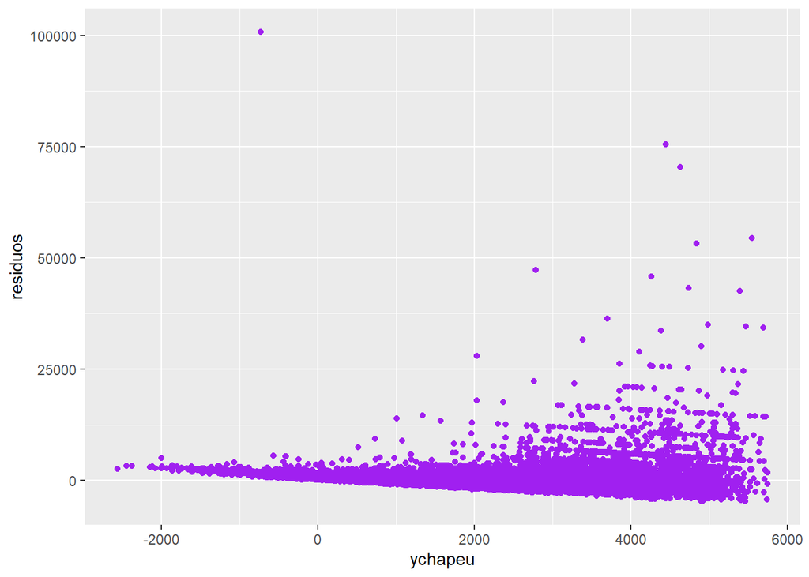

```r
graf<-ggplot(data=df,
       mapping=aes(y=residuos,x=ychapeu))+
    geom_point(col="purple")
graf
```

# 4 Teste para heterocedasticidade: BP

Vamos fazer as duas versões do teste de Breusch Pagan (com a estatística LM e com a estatística F)

H0:
$$Var(\mu \mid x_1,x_2,...,x_k)=\sigma^2$$
(Não há heterocedasticidade)

H1:
$$Var(\mu \mid x_1,x_2,...,x_k) \neq \sigma^2$$
(Há heterocedasticidade)

## 4.1 Manualmente

Vamos fazer a regressão auxiliar (equação 8.14 Wooldridge):

```r
df$residuos2<-MQO$residuals^2 ##residuos ao quadrado
aux<-lm(residuos2~anos_estudo+raca+idade+idade2+sexo,data=df)
```

Vamos salvar o $R^2$ da regressão

```r
R2_u2<-summary(aux)$r.squared
```

Para calcular os graus de liberdade da estatística F ou LM, vamos precisar saber do número de regressores (k) e número de observações da estimação (n).

Por isso, vamos salvar estes números antes de calcular as estatísticas.

Temos 5 regressores. Então k=5. Também devemos salvar o numero de observações da estimação da regressão auxiliar. Para isso pegamos a extensão (length) do vetor do y predito (fitted.values)

```r
k<-5
n<-as.numeric(length(aux$fitted.values))
```

### 4.1.1 Estatística F

Vamos calcular a estatística F (equação 8.15 Wooldridge)

```r
est_f<-(R2_u2/k)/((1-R2_u2)/(n-k-1)) ##equação 8.15

print(est_f)
```

```
## [1] 20.13136
```

Vamos plotar um gráfico da distribuição F para relembrar. (não é necessário fazer este passo! É só para entender a distribuição)

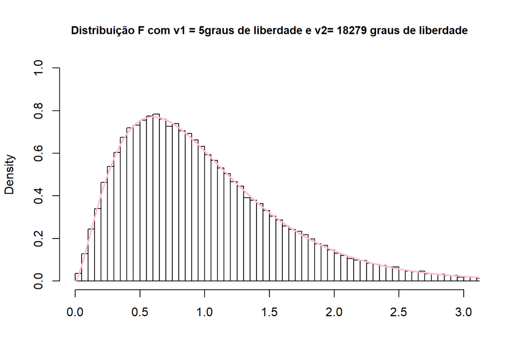

```r
x <- rf(100000, df1 = k, df2 = n-k-1)
hist(x,
     breaks = 'Scott',
     freq = FALSE,
     xlim = c(0,3),
     ylim = c(0,1),
     xlab = '',
     main = (paste0("Distribuição F com v1 = ", k, "graus de liberdade e v2= ", n-k-1," graus de liberdade")), cex.main=0.9)

curve(df(x, df1 = k, df2 = n-k-1), from = 0, to = 4, n = 5000, col= 'pink', lwd=2, add = T)
```

Vamos então calcular o p valor da nossa estatística usando a distribuição $F_{k,n-k-1}$

```r
f.pvalue <- df(est_f,k,n-k-1)

print(f.pvalue)
```

```
## [1] 0.0000000000000000001056254
```

P valor <0,05, rejeita-se a hipótese nula. Ou seja, há evidências de heterocedasticidade.

### 4.1.2 Estatística LM

A estatística LM para heterocedasticidade é o tamanho da amostra multiplicado pelo R-quadrado da equação 8.14.

```r
est_LM<-(n * R2_u2)

print(est_LM)
```

```
## [1] 100.1384
```

Sob H0 a estatítica LM é distribuída assimptoticamente como $\mathcal{X^2_k}$ (Wooldridge, 2011, p.256). Vamos calcular o pvalor:

```r
pchisq(est_LM, k, lower.tail=F)
```

```
## [1] 0.00000000000000000004941844
```

## 4.2 Fazendo o teste com o pacote

```r
bptest(MQO,studentize = F)
```

```
##
##  Breusch-Pagan test
##
## data:  MQO
## BP = 11201, df = 5, p-value < 0.00000000000000022
```

P valor <0,05, rejeita-se a hipótese nula. Ou seja, há evidências de heterocedasticidade.

# 5 Correção de White: Erros padrões robustos

Seja
$$SQT_X=\sum_{i=1}^{n}(x_i-\overline{x})$$

Sabemos que um estimador válido da var $(\hat{\beta})$ é dado por

$\sum_{i=1}^{n}\frac{(x_i-\overline{x})\hat{\mu_i}^2}{SQT_x^2}$

Para regressão múltipla, pode ser mostrado que um estimador de var$(\hat{\beta_j})$ é dado por:

$$\frac{\sum_{i=1}^{n}\hat{r_{ij}^2}\hat{\mu_i}^2}{{SQR_j^2}}$$

$r_{ij}$ representa o i-ésimo resíduo da regressão $x_j$ sobre todas as outras variáveis independentes.

Vamos calcular então esse estimador para a variável anos_estudo. Vamos fazer de duas formas: manualmente e com o pacote

## 5.1 Manualmente

Primeiro vamos calcular o $r_{ij}$ em j= anos_estudo.

```r
Reg_aux=lm(anos_estudo~raca+idade+idade2+sexo,data=df)

df$residuos_aux<-Reg_aux$residuals
```

Vamos calcular o $SQR_j= \sum_{i=1}^{n}r_i^2$

```r
SQR_j<-sum((df$residuos_aux)^2)
```

Vamos estimar o erro padrão robusto do estimador do coeficiente anos_estudo

```r
ep_rob_anos_estudo=sqrt(sum((df$residuos_aux)^2*(df$residuos)^2)/SQR_j^2)


print(ep_rob_anos_estudo)
```

```
## [1] 8.86356
```

## 5.2 Usando o pacote

Usando o pacote, calculamos todos os erros padrões robustos de uma vez só. Na forma manual, fizemos somente para anos_estudo (mas você pode fazer para as outras variáveis)

```r
coeftest(MQO, vcov = vcovHC(MQO, type="HC0"))
```

```
##
## t test of coefficients:
##
##                Estimate  Std. Error  t value              Pr(>|t|)
## (Intercept) -4447.23042   180.96522 -24.5751 < 0.00000000000000022 ***
## anos_estudo   283.76713     8.86356  32.0150 < 0.00000000000000022 ***
## raca          334.63900    35.31387   9.4761 < 0.00000000000000022 ***
## idade         110.62876     9.82972  11.2545 < 0.00000000000000022 ***
## idade2         -0.74381     0.13137  -5.6621         0.00000001518 ***
## sexo          916.82464    41.60377  22.0371 < 0.00000000000000022 ***
## ---
## Signif. codes:  0 '***' 0.001 '**' 0.01 '*' 0.05 '.' 0.1 ' ' 1
```

# 6 Mínimos Quadrados Generalizados

Vamos supor que a variância é uma função da escolaridade do indivíduo.

$$var(u_i|\mathbf{X_i})=\sigma^2h(x)$$

Em que
$$h(x)=exp(educ_i)$$
(lembre-se que a variância tem que ser positiva)

Vamos estimar a mesma regressão da seção 2, mas dividiremos por $\sqrt{exp(educ)}$

Vamos criar cada uma das variáveis transformadas. Vou sempre nomeá-las com um t no final. A função para tirar a raiz quadrada é sqrt (do inglês square root).

```r
df$renda_t<-df$renda/sqrt(exp(df$anos_estudo))
df$raca_t<-df$raca/sqrt(exp(df$anos_estudo))
df$idade_t<-df$idade/sqrt(exp(df$anos_estudo))
df$idade2_t<-df$idade2/sqrt(exp(df$anos_estudo))
df$idade2_t<-df$idade2/sqrt(exp(df$anos_estudo))
df$sexo_t<-df$sexo/sqrt(exp(df$anos_estudo))

df$anos_estudo_t<-df$anos_estudo/sqrt(exp(df$anos_estudo))
```

Agora vamos estimar o modelo transformado.

```r
MQO_t<-lm(renda_t~anos_estudo_t+raca_t+idade_t+idade2_t+sexo_t, data=df)
```

Vamos plotar o gráfico dos novos resíduos com os novos y preditos para poder inspecionar visualmente.

```r
df$residuos_t<-MQO_t$residuals
df$ychapeu_t<-MQO_t$fitted
```

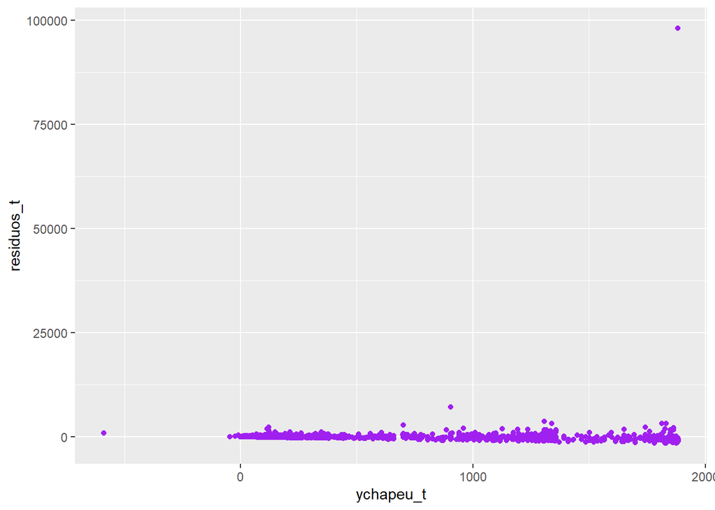

```r
graf<-ggplot(data=df,
       mapping=aes(y=residuos_t,x=ychapeu_t))+
    geom_point(col="purple")
graf
```

# 7 Teste para a heterocedasticidade: White

Vamos verificar se mesmo com MQG há heterocedasticidade.

Na seção 4 fizemos o teste de Breusch pagan. Agora vamos fazer o teste de White.

Isto implicafazer uma regressão com $\hat{u}^2$ como função de todas as variáveis explicativas do nosso modelo, os quadrados destas variáveis e todos os produtos cruzados.

Para eu não precisar escrever os produtos um a um, eu fiz um looping e usei a função paste0. Se você estiver interessado em aprender como faz um looping, cheque [este](https://www.r-bloggers.com/how-to-write-the-first-for-loop-in-r/) tutorial! Ou você também pode elevar as variáveis explicativas conjuntamente ao quadrado.

Se não, você pode escrever manualmente…

```r
df$residuos_t2<-MQO_t$residuals^2 ##residuos ao quadrado

vetor<-c("anos_estudo_t","raca_t","idade_t","idade2_t","sexo_t")

produtos_cruz<-c()
for(i in 1:length(vetor)){
  for(k in 0:(5-i)){
  j<-i+k
  produtos_cruz<-c(produtos_cruz,paste0(vetor[i],":",vetor[j]))
}} ##produtos cruzados

produtos_cruz<-paste0(produtos_cruz,collapse = "+")


##fazendo o quadrado das variaveis
df$anos_estudo_t2<-df$anos_estudo_t^2
df$raca_t2<-df$raca_t^2
df$idade_t2<-df$idade_t^2
df$idade2_t2<-df$idade2_t^2
df$sexo_t2<-df$sexo_t^2
formula_regressao<-as.formula(paste0("residuos_t2~anos_estudo_t+raca_t+idade_t+idade2_t+sexo_t+                               anos_estudo_t2+raca_t2+idade_t2+idade2_t2+sexo_t2+",produtos_cruz))
```

Tendo preparado a nossa formula da regressão auxiliar, vamos “rodar” a regressão

```r
aux_white<-lm(formula=formula_regressao,df)


summary(aux_white)
```

```
##
## Call:
## lm(formula = formula_regressao, data = df)
##
## Residuals:
##        Min         1Q     Median         3Q        Max
## -263753600     -97314      59309     146541 9459993226
##
## Coefficients:
##                             Estimate    Std. Error t value             Pr(>|t|)
## (Intercept)               -211519.09     831615.02  -0.254             0.799230
## anos_estudo_t            23796064.37   15308024.32   1.554             0.120087
## raca_t                   17878059.08   55488884.88   0.322             0.747311
## idade_t                 -10695123.73    3211893.94  -3.330             0.000871
## idade2_t                   117314.08      42317.32   2.772             0.005573
## sexo_t                  -23018910.89   57380922.02  -0.401             0.688307
## anos_estudo_t2           31769938.08   28808118.16   1.103             0.270123
## raca_t2                 -74205812.95   81807845.56  -0.907             0.364379
## idade_t2                   553461.87     134109.89   4.127           0.00003693
## idade2_t2                      71.65         15.07   4.755           0.00000200
## sexo_t2                 208401544.86   82701347.84   2.520             0.011746
## anos_estudo_t:raca_t    -41326873.99   59748917.16  -0.692             0.489150
## anos_estudo_t:idade_t     2844626.69    2893862.35   0.983             0.325627
## anos_estudo_t:idade2_t     -35210.89      47644.72  -0.739             0.459898
## anos_estudo_t:sexo_t     50658024.87   62463639.05   0.811             0.417376
## raca_t:idade_t            9070277.73    2502162.78   3.625             0.000290
## raca_t:idade2_t           -103953.44      25408.57  -4.091           0.00004308
## raca_t:sexo_t          -117202256.73   12998632.61  -9.017 < 0.0000000000000002
## idade_t:idade2_t           -12569.93       2799.00  -4.491           0.00000714
## idade_t:sexo_t           -9854916.33    2493983.68  -3.951           0.00007796
## idade2_t:sexo_t            115134.18      25485.66   4.518           0.00000629
##
## (Intercept)
## anos_estudo_t
## raca_t
## idade_t                ***
## idade2_t               **
## sexo_t
## anos_estudo_t2
## raca_t2
## idade_t2               ***
## idade2_t2              ***
## sexo_t2                *
## anos_estudo_t:raca_t
## anos_estudo_t:idade_t
## anos_estudo_t:idade2_t
## anos_estudo_t:sexo_t
## raca_t:idade_t         ***
## raca_t:idade2_t        ***
## raca_t:sexo_t          ***
## idade_t:idade2_t       ***
## idade_t:sexo_t         ***
## idade2_t:sexo_t        ***
## ---
## Signif. codes:  0 '***' 0.001 '**' 0.01 '*' 0.05 '.' 0.1 ' ' 1
##
## Residual standard error: 70610000 on 18264 degrees of freedom
## Multiple R-squared:  0.01741,    Adjusted R-squared:  0.01634
## F-statistic: 16.18 on 20 and 18264 DF,  p-value: < 0.00000000000000022
```

Agora vamos calcular a estatítica de teste LM_white

```r
R2_u2w<-summary(aux_white)$r.squared #rquadrado da reg auxilia
n_w<-as.numeric(length(aux$fitted.values))#numero de observacoes da amostra
k_w<-nrow(summary(aux_white)$coefficients)#numero de regressores

LM_white<-n_w * R2_u2w#estatistica de teste LM

print(LM_white)
```

```
## [1] 318.418
```

Vamos calcular o p-valor:

```r
pchisq(LM_white, k_w, lower.tail=F)
```

```
## [1] 0.0000000000000000000000000000000000000000000000000000005588521
```